# HealthCareAndCauseOfDeath.Rmd

Herbert Gutierrez, Ryan Wechter, Varun Parameswaran

October 16, 2015

## Health Care Spending and Causes of Death by State

### CS329E: Project 3

### Introduction

This is Project 3 for Dr. Cannata’s Data Visualization class. In this project, we worked with two datasets: national healthcare expenditures and causes of death. Correlating the two would help determine the effectiveness of hospitals and how the statistics in these two tables vary by state and region.

#### RStudio Configuration:

### Loading our data from the Oracle Database

#### Dataset 1: National Healthcare Expenditures

We modified the R script given to us to create a SQL code that would create the table in the Oracle Database. We then loaded our data and could connect to the database to create our data frame in RStudio.

```r
source("../02 Data Wrangling/Project3_ETL_Data1.R", echo = TRUE)
```

```
##
## > require("ggplot2")
```

```
##
## > require("gplots")
```

```
##
## > require("grid")
```

```
##
## > require("RCurl")
```

```
##
## > require("reshape2")
```

```
##
## > require("tableplot")
```

```
##
## > require("tidyr")
```

```
##
## > require("dplyr")
```

```
##
## > require("jsonlite")
```

```
##
## > require("lubridate")
```

```
##
## > NHCE <- data.frame(fromJSON(getURL(URLencode("129.152.144.84:5001/rest/native/?query=\"select * from NHCE\""),
## +     httpheader = c(DB = "jdbc:orac ..." ... [TRUNCATED]
##
## > summary(NHCE)
##       CODE
##  Min.   : 1
##  1st Qu.: 3
##  Median : 6
##  Mean   : 6
##  3rd Qu.: 9
##  Max.   :11
##
##                                                                  ITEM
##  Dental Services (Millions of Dollars)                             : 60
##  Durable Medical Products (Millions of Dollars)                    : 60
##  Home Health Care (Millions of Dollars)                            : 60
##  Hospital Care (Millions of Dollars)                               : 60
##  Nursing Home Care (Millions of Dollars)                           : 60
##  Other Health, Residential, and Personal Care (Millions of Dollars): 60
##  (Other)                                                           :300
##         COUNTRYGROUP REGION_NUMBER       REGION_NAME       STATE_NAME
##  Region       : 88   Min.   :0.00   Southeast  :143   null      : 88
##  State        :561   1st Qu.:2.75   Plains     : 88   Alabama   : 11
##  United States: 11   Median :5.00   Far West   : 77   Alaska    : 11
##                      Mean   :4.40   Mideast    : 77   Arizona   : 11
##                      3rd Qu.:6.00   New England: 77   Arkansas  : 11
##                      Max.   :8.00   Great Lakes: 66   California: 11
##                                     (Other)    :132   (Other)   :517
##      Y1980               Y1981               Y1982
##  Min.   :     0.97   Min.   :     0.67   Min.   :     0.75
##  1st Qu.:    54.67   1st Qu.:    63.87   1st Qu.:    72.44
##  Median :   205.41   Median :   236.86   Median :   269.98
##  Mean   :  1973.66   Mean   :  2290.21   Mean   :  2574.82
##  3rd Qu.:   859.98   3rd Qu.:  1023.74   3rd Qu.:  1141.94
##  Max.   :217102.31   Max.   :251922.64   Max.   :283230.28
##
##      Y1983               Y1984              Y1985
##  Min.   :     1.05   Min.   :     1.3   Min.   :     1.5
##  1st Qu.:    81.09   1st Qu.:    93.4   1st Qu.:   106.8
```

[output cut: 106 more lines]

```
## 6  4605.288  4686.205  5088.643  5322.095  5390.471  6141.088  6149.393
##       Y1999     Y2000     Y2001     Y2002     Y2003     Y2004     Y2005
## 1 16709.332 17472.010 18997.119 20964.803 22799.943 24926.918 27021.092
## 2  7543.153  8027.292  8799.083  9800.905 10647.715 11460.916 12308.264
## 3 29223.719 30945.941 33653.434 36527.695 39509.426 42287.031 45910.590
## 4  4324.187  4501.950  4836.387  5151.761  5451.930  5780.611  6259.666
## 5  3638.930  3719.507  3979.438  4219.751  4500.096  4892.164  5313.629
## 6  6799.146  7365.483  8019.231  8990.266  9656.697 10461.998 11473.283
##       Y2006     Y2007     Y2008     Y2009 AVERAGE_ANNUAL_PERCENT_GROWTH
## 1 28806.225 29948.602 31355.848 33469.195                           6.9
## 2 13262.045 13931.029 14768.442 15235.060                           7.4
## 3 48466.289 52340.715 55801.410 59095.730                           7.3
## 4  6584.923  6888.581  7176.855  7671.679                           6.7
## 5  5775.087  6114.813  6478.738  6873.769                           6.6
## 6 12354.697 13109.384 13672.916 14300.170                           7.6
```

#### Dataset 2: Cause of Death

```r
source("../02 Data Wrangling/Project3_ETL_Data2.R", echo = TRUE)
```

```
##
## > COD <- data.frame(fromJSON(getURL(URLencode("129.152.144.84:5001/rest/native/?query=\"select * from COD\""),
## +     httpheader = c(DB = "jdbc:oracle ..." ... [TRUNCATED]
##
## > summary(COD)
##                                              X113_CAUSE_NAME
##  Accidents (unintentional injuries) (V01-X59,Y85-Y86): 780
##  All Causes                                          : 780
##  Alzheimers disease (G30)                            : 780
##  Chronic liver disease and cirrhosis (K70,K73-K74)   : 780
##  Chronic lower respiratory diseases (J40-J47)        : 780
##  Diabetes mellitus (E10-E14)                         : 780
##  (Other)                                             :6802
##                                CAUSE_NAME             STATE
##  All Causes                         : 780   Wisconsin    :  239
##  Alzheimers disease                 : 780   United States:  237
##  Cancer                             : 780   Utah         :  237
##  Chronic liver disease and cirrhosis: 780   Washington   :  237
##  CLRD                               : 780   West Virginia:  237
##  Diabetes                           : 780   Tennessee    :  235
##  (Other)                            :6802   (Other)      :10060
##       YEAR          DEATHS             AADR
##  Min.   :1999   Min.   :     20   Min.   :   1.38
##  1st Qu.:2002   1st Qu.:    332   1st Qu.:   9.75
##  Median :2006   Median :    986   Median :  21.14
##  Mean   :2006   Mean   :  11537   Mean   :  97.94
##  3rd Qu.:2010   3rd Qu.:   3104   3rd Qu.:  49.68
##  Max.   :2013   Max.   :2596993   Max.   :1087.30
##
##
## > head(COD)
##                                X113_CAUSE_NAME CAUSE_NAME
## 1 Chronic lower respiratory diseases (J40-J47)       CLRD
## 2 Chronic lower respiratory diseases (J40-J47)       CLRD
## 3 Chronic lower respiratory diseases (J40-J47)       CLRD
## 4 Chronic lower respiratory diseases (J40-J47)       CLRD
## 5 Chronic lower respiratory diseases (J40-J47)       CLRD
## 6 Chronic lower respiratory diseases (J40-J47)       CLRD
##                  STATE YEAR DEATHS  AADR
## 1             Delaware 1999    327 42.74
## 2 District of Columbia 1999    166 29.89
## 3              Florida 1999   9131 43.08
## 4              Georgia 1999   3056 49.06
## 5               Hawaii 1999    290 24.01
## 6                Idaho 1999    568 49.54
```

## Graph 1: Hospital Spending per Cancer Death, by state

```
##
## > df1 <- COD %>% select(STATE, YEAR, DEATHS, AADR, CAUSE_NAME) %>%
## +     filter(YEAR == 1999 & CAUSE_NAME == "Cancer")
##
## > df2 <- NHCE %>% select(ITEM, STATE_NAME, Y1999, CODE,
## +     COUNTRYGROUP) %>% filter(CODE == 2, COUNTRYGROUP != "Region") %>%
## +     rename(STATE = .... [TRUNCATED]
##
## > df <- dplyr::full_join(df1, df2, by = "STATE")
```

```
##
## > df %>% ggplot(aes(x = reorder(STATE, SPENDING/DEATHS),
## +     y = SPENDING/DEATHS, fill = STATE)) + geom_bar(stat = "identity") +
## +     theme(legen .... [TRUNCATED]
```

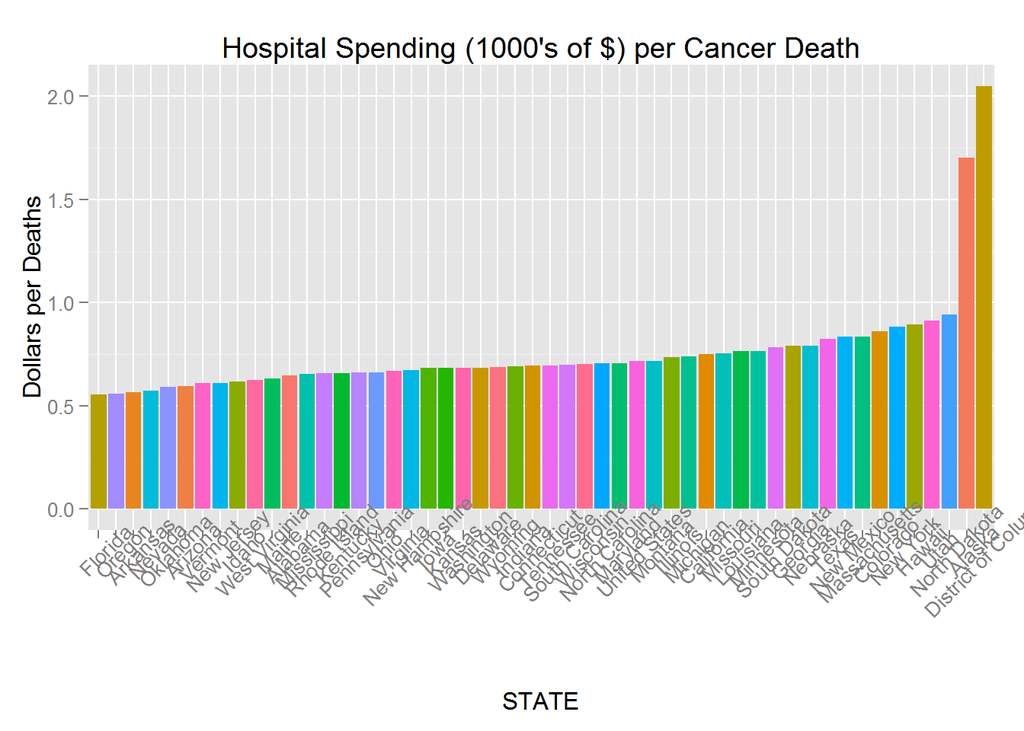

```r
source("../02 Data Wrangling/Graph1.R", echo = TRUE)
```

#### Interpretation

This graph shows the ratio of the total number of dollars (1000’s) spent by hospitals in each state to the number of cancer deaths in the state for the year 1999. This ratio does not represent the average cost of a cancer patient to a hospital because the data excludes other types of death and does not account for other hospital expenses. This graph is meant to illustrate the excessive over charging of patients for hospital care in the United States. According to Beckers Hospital Review the average cost to a patient for a hospital stay in the United States is approximately $10,000 as compared to the cost to the hospital which ranges from as low as $500 in Florida to as high as $2000 in the District of Columbia.

## Graph 2: Healthcare Expenditures per Death in Texas

```
##
## > df1 <- COD %>% select(STATE, YEAR, DEATHS, AADR, CAUSE_NAME) %>%
## +     filter(CAUSE_NAME == "All Causes", STATE == "Texas", YEAR >=
## +         1999 .... [TRUNCATED]
##
## > df2 <- NHCE %>% select(ITEM, STATE_NAME, CODE, COUNTRYGROUP,
## +     Y1999, Y2000, Y2001, Y2002, Y2003, Y2004, Y2005, Y2006, Y2007,
## +     Y2008, Y20 .... [TRUNCATED]
##
## > df <- dplyr::left_join(df1, df2, by = "YEAR")
##
## > df %>% ggplot(aes(x = YEAR, y = Spending/DEATHS)) +
## +     geom_line(stat = "identity") + labs(x = "Year", y = "Healthcare Expenditure per Death",
##  .... [TRUNCATED]
```

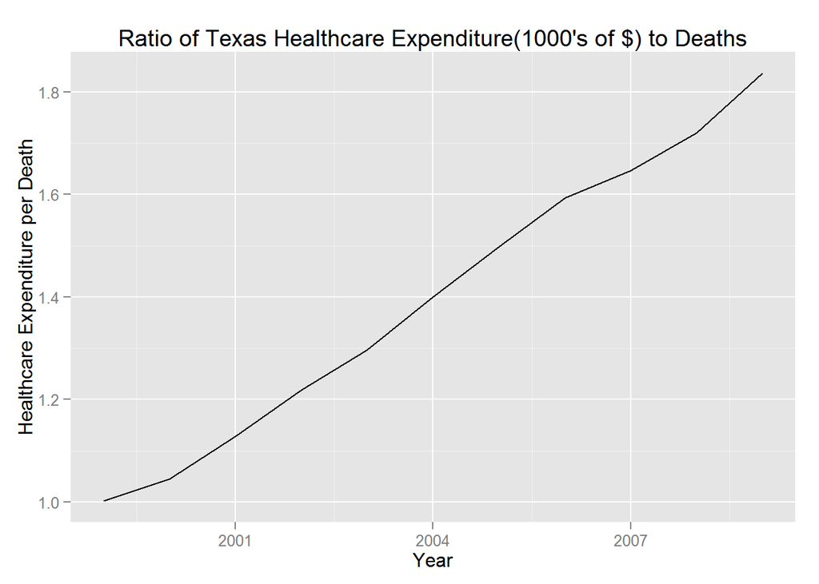

```r
source("../02 Data Wrangling/Graph2.R", echo = TRUE)
```

## Graph 3: Suicide rates and prescription drugs grouped by state

```
##
## > df1 <- COD %>% select(STATE, YEAR, AADR, CAUSE_NAME,
## +     DEATHS) %>% filter(YEAR == 2009 & CAUSE_NAME == "Suicide")
##
## > df2 <- NHCE %>% filter(CODE == 7, COUNTRYGROUP ==
## +     "State") %>% select(ITEM, STATE_NAME, Y2009) %>% rename(STATE = STATE_NAME,
## +     SPENDING .... [TRUNCATED]
##
## > df <- dplyr::inner_join(df1, df2, by = "STATE")
```

```
##
## > ggplot() + coord_cartesian() + scale_x_continuous() +
## +     scale_y_continuous() + labs(title = "Prescription Drug Spending vs. Deaths by Suicide") .... [TRUNCATED]
```

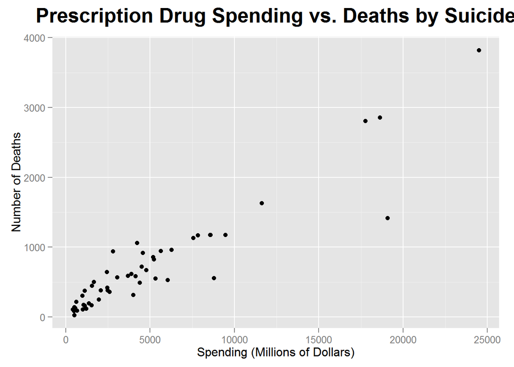

```r
source("../02 Data Wrangling/Graph3.R", echo = TRUE)
```